# Univariate Plots Section

```
##   5   6   7   4   8   3
## 681 638 199  53  18  10
```

```
quality众数为5，其次为6。数据集的红酒品质整体处于中等偏上。


非挥发酸度主要是酒石酸，将酒石酸与柠檬酸相加，创建有机酸变量。将总二氧化硫与游离二氧化硫相加，创建溶解气体变量。将氯化物与硫酸盐相加，创建矿物盐变量。将品质由int型转为分类变量。
```

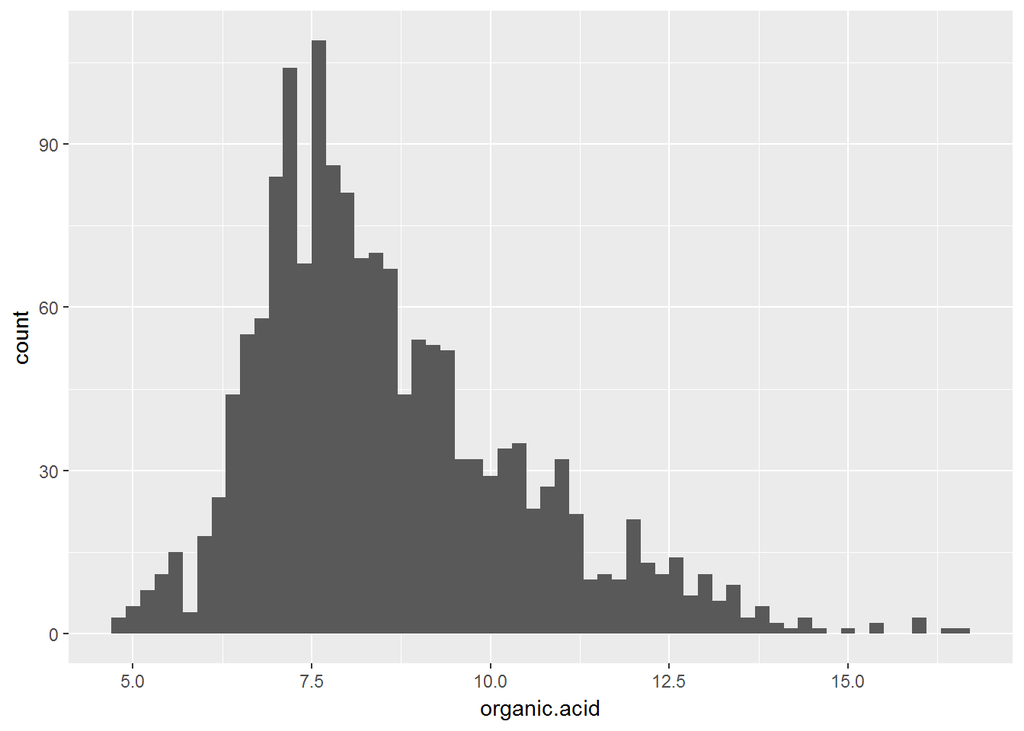

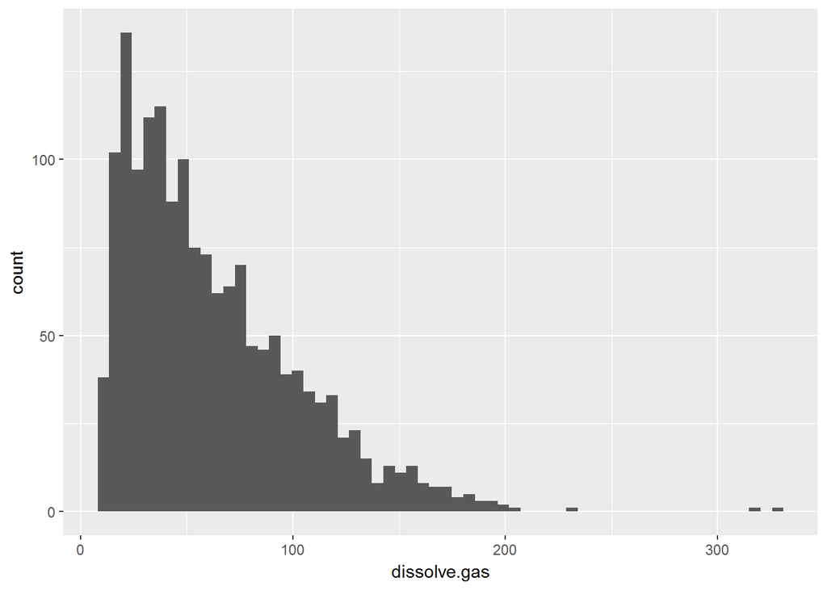

```
##    Min. 1st Qu.  Median    Mean 3rd Qu.    Max.
##    9.00   31.00   52.00   62.34   86.00  326.50
```

```
溶解气体是长尾数据，对其进行对数转换，可以看到分布集中很多。
```

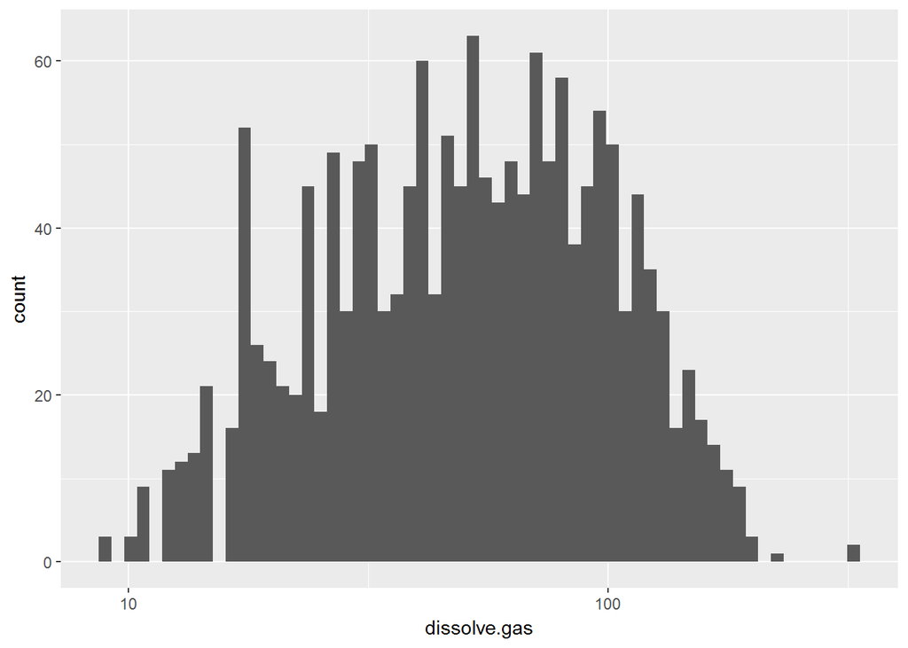

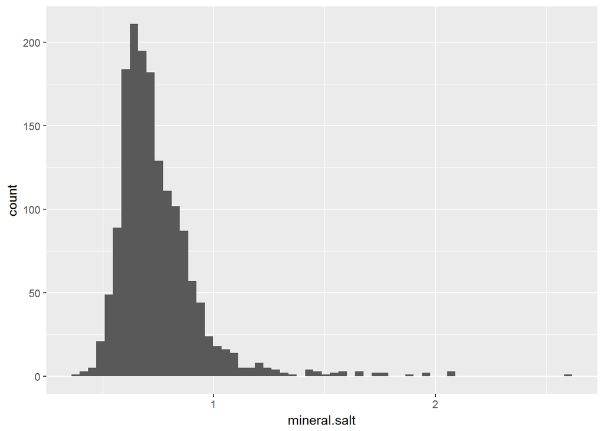

# Univariate Analysis

### What is the structure of your dataset?

```
数据集有13个变量，11个是输入变量，一个是品质变量，一个是计数变量。有1599条记录。11个输入变量分别是，固定酸度、挥发酸度、柠檬酸、残糖、氯化物、游离二氧化硫、总二氧化硫、密度、pH、硫酸盐、酒精，所有变量都是num型。
```

### What is/are the main feature(s) of interest in your dataset?

```
残糖含量、有机酸含量、酒精含量，应该是影响葡萄酒品质的最主要因素。酒精是最直接的发酵产物，有机酸可以平衡口感，抗氧化，主要包括酒石酸和柠檬酸，残糖可以带来葡萄酒的甜味。
```

### What other features in the dataset do you think will help support your investigation into your feature(s) of interest?

```
矿物盐的含量，溶解气体的含量，总酸、水分都会影响葡萄酒品质。但相对来说，矿物盐含量应该是接下来影响葡萄酒品质的主要因素。
```

### Did you create any new variables from existing variables in the dataset?

```
为了更方便的研究主要因素，我增加了三个变量，有机酸含量、矿物盐含量、溶解气体含量。有机酸含量等于固定酸度与柠檬酸之和，矿物盐含量等于氯化物和硫酸盐之和，溶解气体含量等于游离二氧化硫与总二氧化硫之和。
```

### Of the features you investigated, were there any unusual distributions? Did you perform any operations on the data to tidy, adjust, or change the form of the data? If so, why did you do this?

[output not shown]

# Bivariate Plots Section

```
##                  residual.sugar organic.acid     alcohol mineral.salt
## residual.sugar      1.000000000    0.1213350  0.04207544   0.01850939
## organic.acid        0.121334969    1.0000000 -0.04578490   0.20494263
## alcohol             0.042075437   -0.0457849  1.00000000   0.02841855
## mineral.salt        0.018509391    0.2049426  0.02841855   1.00000000
## dissolve.gas        0.212520770   -0.1203322 -0.18436210   0.05218883
## sulphates           0.005527121    0.2021617  0.09359475   0.97375735
## pH                 -0.085652422   -0.6895844  0.20563251  -0.23855212
## density             0.355283371    0.6573780 -0.49617977   0.18027170
## volatile.acidity    0.001917882   -0.2948472 -0.20228803  -0.21536381
## quality             0.013731637    0.1385265  0.47616632   0.19032713
##                  dissolve.gas    sulphates          pH     density
## residual.sugar     0.21252077  0.005527121 -0.08565242  0.35528337
## organic.acid      -0.12033222  0.202161691 -0.68958445  0.65737801
## alcohol           -0.18436210  0.093594750  0.20563251 -0.49617977
## mineral.salt       0.05218883  0.973757351 -0.23855212  0.18027170
## dissolve.gas       1.00000000  0.048067459 -0.03571535  0.05204899
## sulphates          0.04806746  1.000000000 -0.19664760  0.14850641
## pH                -0.03571535 -0.196647602  1.00000000 -0.34169933
## density            0.05204899  0.148506412 -0.34169933  1.00000000
## volatile.acidity   0.05920481 -0.260986685  0.23493729  0.02202623
## quality           -0.16289473  0.251397079 -0.05773139 -0.17491923
##                  volatile.acidity     quality
## residual.sugar        0.001917882  0.01373164
## organic.acid         -0.294847154  0.13852654
## alcohol              -0.202288027  0.47616632
## mineral.salt         -0.215363814  0.19032713
## dissolve.gas          0.059204814 -0.16289473
## sulphates            -0.260986685  0.25139708
## pH                    0.234937294 -0.05773139
## density               0.022026232 -0.17491923
## volatile.acidity      1.000000000 -0.39055778
## quality              -0.390557780  1.00000000
```

```
pH值和有机酸含量显著相关，有机酸含量和酒精含量与密度显著相关。与品质相关性最强两个因素分别是酒精（0.476）、挥发性酸（-0.391）。
```

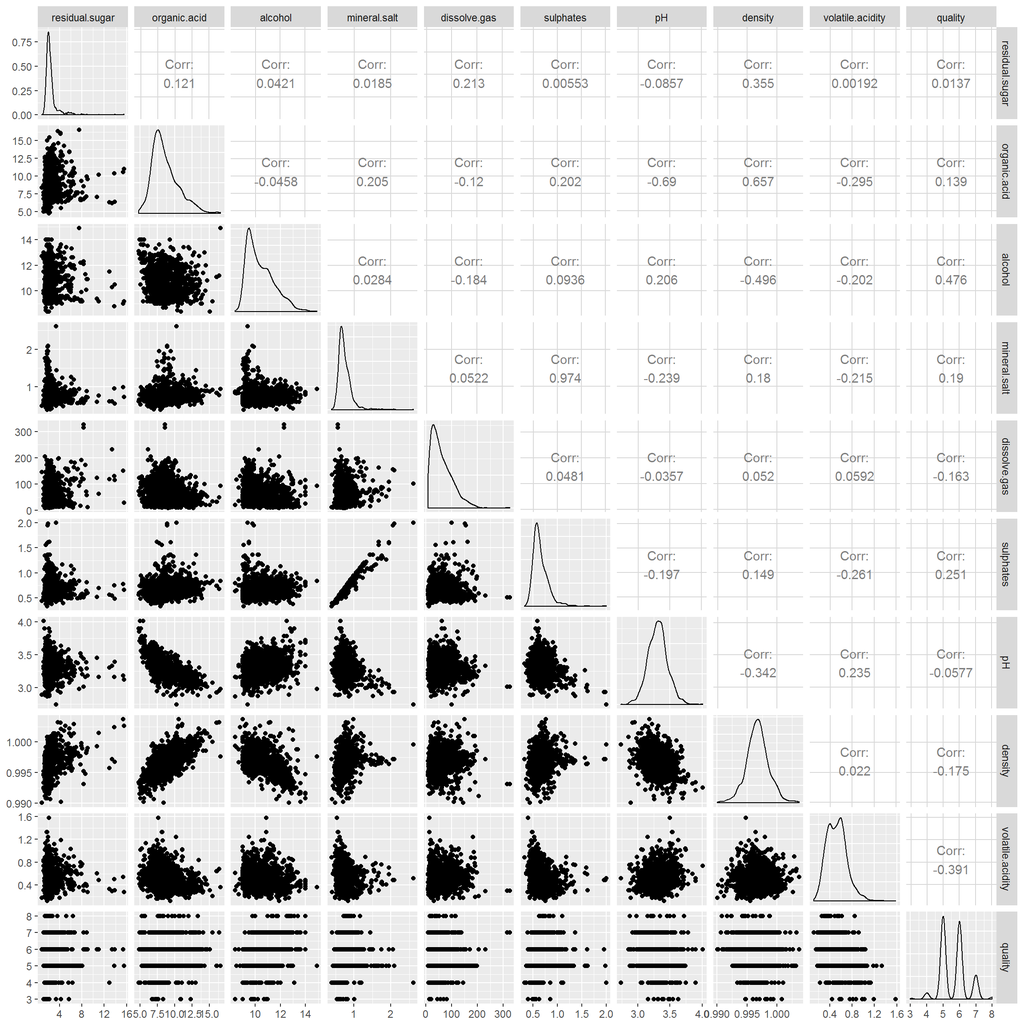

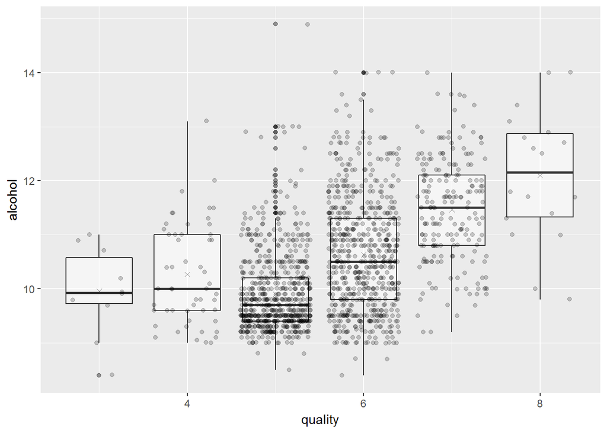

```
## # A tibble: 6 x 6
##   quality mean_alcohol median_alcohol min_alcohol max_alcohol     n
##     <int>        <dbl>          <dbl>       <dbl>       <dbl> <int>
## 1       3     9.955000          9.925         8.4        11.0    10
## 2       4    10.265094         10.000         9.0        13.1    53
## 3       5     9.899706          9.700         8.5        14.9   681
## 4       6    10.629519         10.500         8.4        14.0   638
## 5       7    11.465913         11.500         9.2        14.0   199
## 6       8    12.094444         12.150         9.8        14.0    18
```

[output not shown]

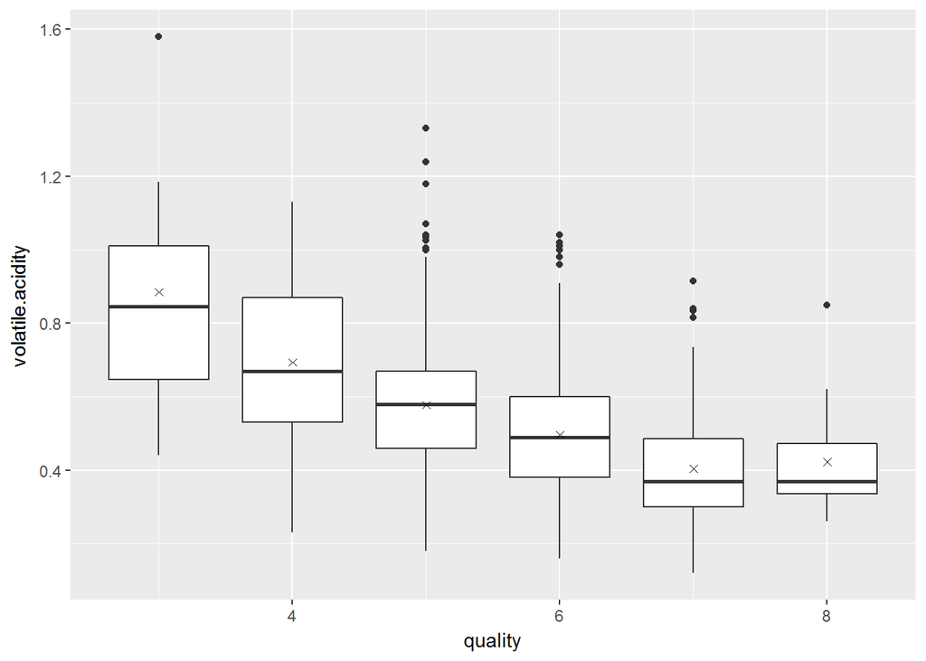

```
## # A tibble: 6 x 6
##   quality mean_volatile.acidity median_volatile.acidity
##     <int>                 <dbl>                   <dbl>
## 1       3             0.8845000                   0.845
## 2       4             0.6939623                   0.670
## 3       5             0.5770411                   0.580
## 4       6             0.4974843                   0.490
## 5       7             0.4039196                   0.370
## 6       8             0.4233333                   0.370
## # ... with 3 more variables: min_volatile.acidity <dbl>,
## #   max_volatile.acidity <dbl>, n <int>
```

```
同样，绘制挥发性酸与品质之间的箱线图，可以发现，呈现一个较为明显的负相关性。再分别观察下，其他变量与品质的箱线图。
```

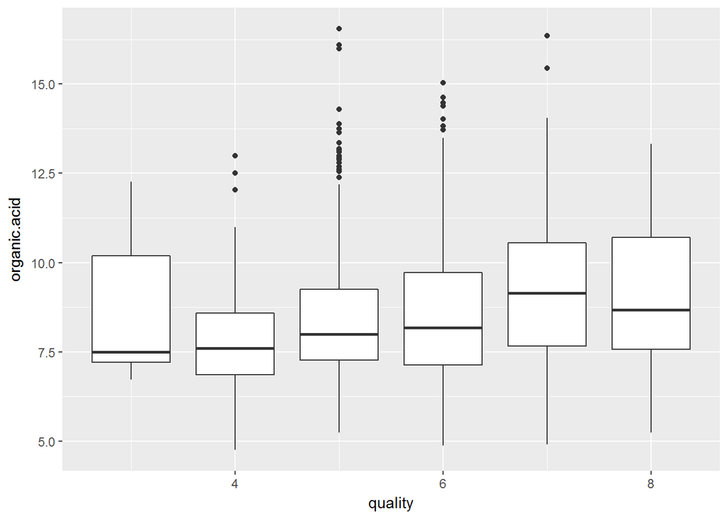

```
## # A tibble: 6 x 6
##   quality mean_organic.acid median_organic.acid min_organic.acid
##     <int>             <dbl>               <dbl>            <dbl>
## 1       3          8.531000               7.500             6.72
## 2       4          7.953396               7.600             4.75
## 3       5          8.410940               8.000             5.24
## 4       6          8.621003               8.180             4.87
## 5       7          9.247538               9.150             4.90
## 6       8          8.957778               8.675             5.24
## # ... with 2 more variables: max_organic.acid <dbl>, n <int>
```

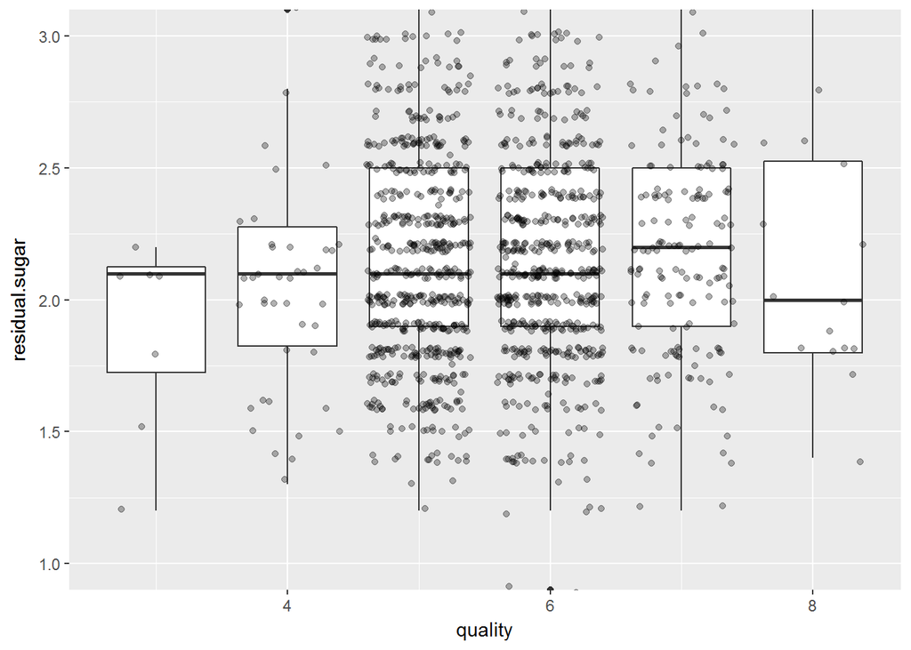

[output not shown]

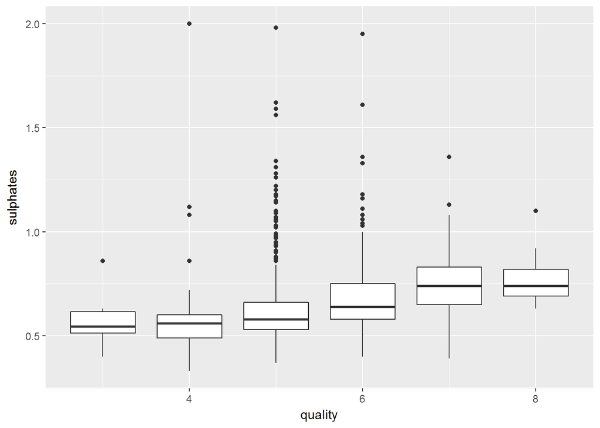

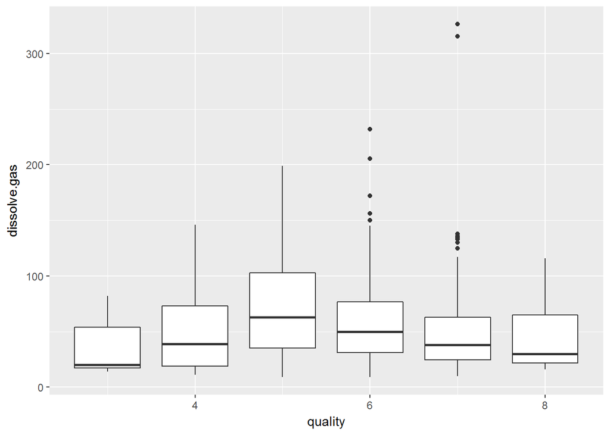

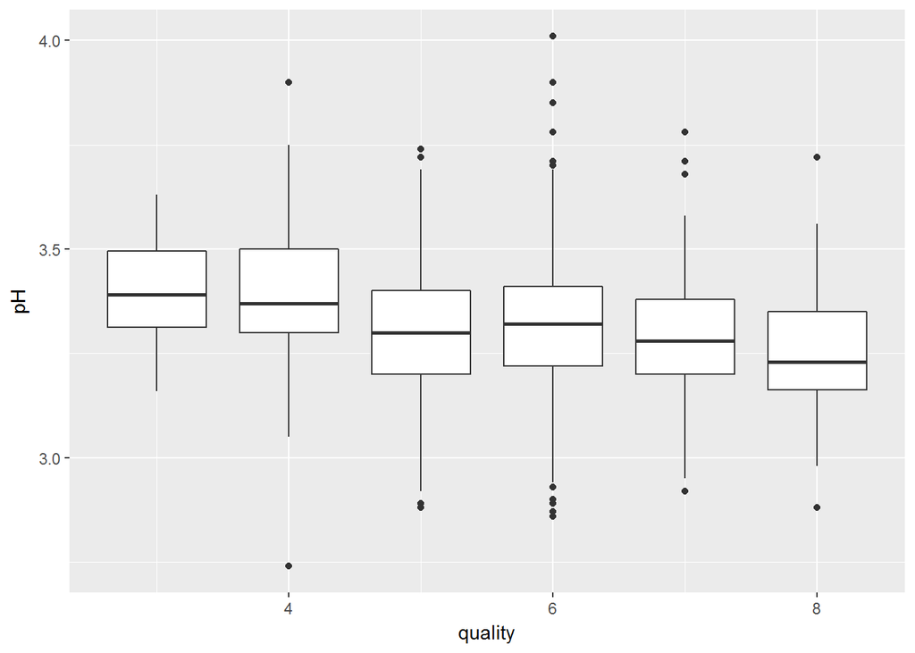

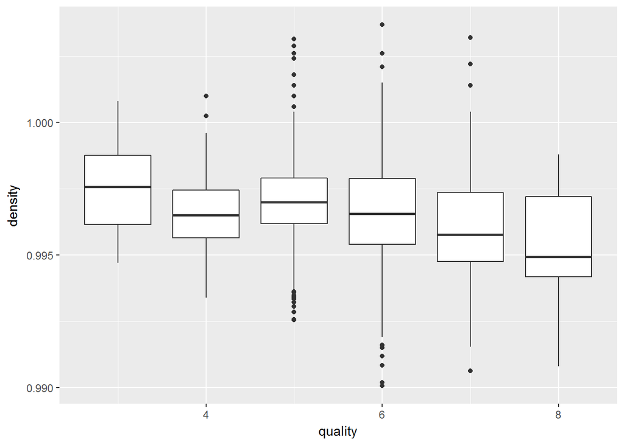

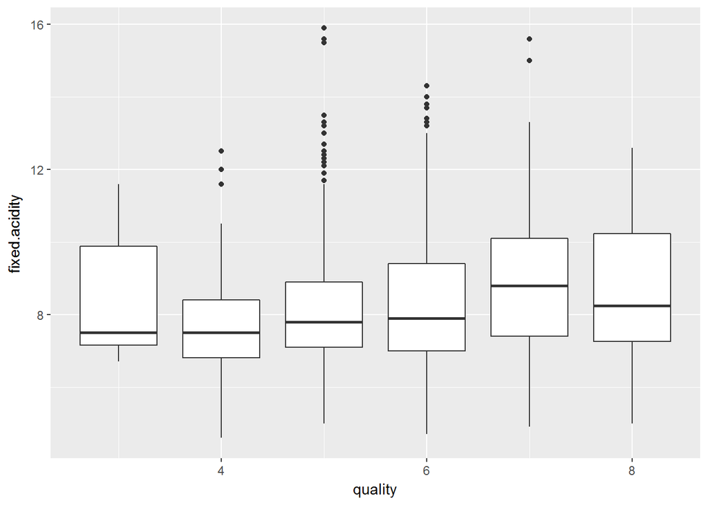

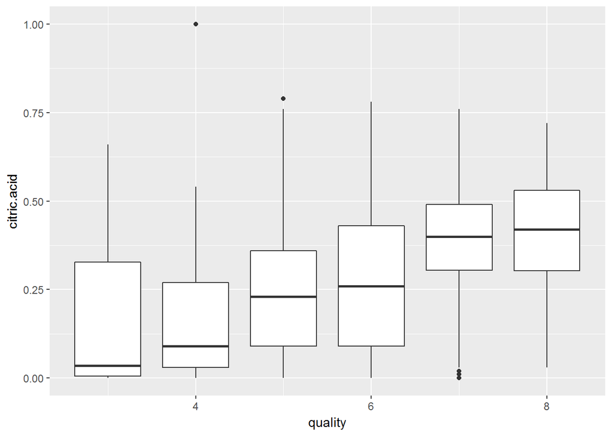

```
## [1] 0.2263725
```

```
## # A tibble: 6 x 6
##   quality mean_citric.acid median_citric.acid min_citric.acid
##     <int>            <dbl>              <dbl>           <dbl>
## 1       3        0.1710000              0.035            0.00
## 2       4        0.1741509              0.090            0.00
## 3       5        0.2436858              0.230            0.00
## 4       6        0.2738245              0.260            0.00
## 5       7        0.3751759              0.400            0.00
## 6       8        0.3911111              0.420            0.03
## # ... with 2 more variables: max_citric.acid <dbl>, n <int>
```

```
可以看出，之前我将固定酸与柠檬酸合成变量有机酸，与品质变量相关性并不高。但是单独来看，柠檬酸与品质是有较明显的相关性，相关系数0.23。
```